# T0-4_r5-5-0-15_50agents

Hirasawa Wakana

2025-07-07

Abstract

強化学習エージェントから生成された行動データに対して、フルモデルをフィッティングして、パラメータがうまく推定されているかを確認した。

# 1.目的

### 1.1【大きい目的】

人間が社会規範に従うメカニズムを明らかにする

そのために、既存の複数の理論が提案する「規範遵守のメカニズム」が、互いにどのように異なり、どのように識別可能であるかを明らかにしたい

### 1.2【中ぐらいの目的】

フィッティング（パラメータリカバリー）を行うことで以下のことを確認する

強化学習エージェントから生成された行動データに対して、それぞれの強化学習モデルをフィッティングして、パラメータがうまく推定されているかを確認する

たとえば学習率 = 0.6、 逆温度 = 0.2という値の下で生成されたデータに、モデルをフィッティングしたとき、この2つの値が推定されないならば、モデルフィッティングがあまりうまくいかないことを意味する

### 1.3【小さい目的】

課題ごとでフィッティング結果にどのような違いがあるかを確認する。

# 2.課題設定

t0では、行動A（規範的な行動）を確率P(A)で、行動B（非規範的な行動）を確率1-P(A)で選択する

行動Aを選択すると確率T(r1| t0, A)でr1に、1-T(r2| t0, A)でr2の報酬を受け取る

行動Bを選択すると確率T(r3| t0, B)でr3に、1-T(r4| t0, B)でr4の報酬を受け取る

## 2.1 実施内容

各モデルから1つのパラメータ条件を選び、フィッティングする

フィッティング結果に対して、それぞれのモデルのパラメータにおけるtraceplotと事後分布をプロットする

フィッティング結果に対して、実際の選択確率と事後予測プロットの比較をする

# 3.データの生成

## 3.1データの生成に使用したコード (Python)

**[データ生成のリンクはこちら](https://colab.research.google.com/drive/1hDCslydxCbMWNUY5WKksNuKylMJ8vX2Q?authuser=1)**

```
# ver4

import numpy as np
import pandas as pd
import matplotlib.pyplot as plt
import seaborn as sns
from tqdm import tqdm
import os, re
from matplotlib.colors import to_hex
from matplotlib import colormaps

def fmt_dash(x, digits=1):
    return str(round(x, digits)).replace('.', '-')

def join_dash(seq):
    return '-'.join(map(str, seq))

T = 0.7
r_base = [5, 5, 0, 15]
t_max = 100
n_agents = 50
alpha_list = [0.1, 0.5, 0.9]
beta_list = [0.1, 1.0, 1.9]

baseline = (1 - T) * r_base[3]
Q_init = [round(baseline, 1), round(baseline * 2, 1), round(baseline * 10, 1)]
r_int = [round(baseline, 1), round(baseline * 2, 1), round(baseline * 10, 1)]

agent_types = ["habit", "first_value_reward", "additional_internalized"]

T_str = fmt_dash(T)
rbase_str = join_dash(r_base)
base_folder_name = f"T{T_str}_r{rbase_str}_{n_agents}agents"

outdir = f"{base_folder_name}_rep1"
csv_dir = os.path.join(outdir, "csv")
png_dir = os.path.join(outdir, "png")
os.makedirs(csv_dir, exist_ok=True)
os.makedirs(png_dir, exist_ok=True)

all_results = []

temp_labels = []
for agent_type in agent_types:
    if agent_type == "first_value_reward":
        for q in Q_init:
            temp_labels.append(f"{agent_type}_Q_init{q}")
    elif agent_type == "additional_internalized":
        for r in r_int:
            temp_labels.append(f"{agent_type}_r_int{r}")
    else:
        temp_labels.append("habit")

habit_colors = {"habit": "#1f77b4"}
fv_labels = sorted([lab for lab in temp_labels if "first_value_reward" in lab],
                   key=lambda x: float(re.search(r"Q_init([0-9.]+)", x).group(1)))
int_labels = sorted([lab for lab in temp_labels if "additional_internalized" in lab],
                    key=lambda x: float(re.search(r"r_int([0-9.]+)", x).group(1)))

fv_cmap = colormaps.get_cmap("Oranges")
int_cmap = colormaps.get_cmap("YlGn")

fv_colors = {lab: to_hex(fv_cmap(0.3 + 0.1 * i)) for i, lab in enumerate(fv_labels)}
int_colors = {lab: to_hex(int_cmap(0.3 + 0.1 * i)) for i, lab in enumerate(int_labels)}
palette_dict = {**habit_colors, **fv_colors, **int_colors}

for agent_type in agent_types:
    extra_param_list = Q_init if agent_type == "first_value_reward" else r_int if agent_type == "additional_internalized" else [None]
    for extra_param in extra_param_list:
        for alpha in tqdm(alpha_list, desc=f"{agent_type}, param={extra_param}"):
            for beta in beta_list:
                raw_data = []
                pA_matrix = np.zeros((n_agents, t_max))
                for n in range(n_agents):
                    Q = np.zeros((2, t_max))
                    pA = np.zeros(t_max)
                    r1, r2, r3, r4 = r_base
                    if agent_type == "first_value_reward":
                        Q[0, 0] += extra_param
                    elif agent_type == "additional_internalized":
                        r1 += extra_param
                        r2 += extra_param
                    for t in range(t_max):
                        pA[t] = 1 / (1 + np.exp(-beta * (Q[0, t] - Q[1, t])))
                        if np.random.rand() < pA[t]:
                            a = 0
                            r = r1 if np.random.rand() < T else r2
                        else:
                            a = 1
                            r = r3 if np.random.rand() < T else r4
                        if t < t_max - 1:
                            Q[a, t + 1] = Q[a, t] + alpha * (r - Q[a, t])
                        raw_data.append({"ID": n, "round": t, "choice": a, "reward": r})
                    pA_matrix[n, :] = pA
                param_str = "na" if extra_param is None else fmt_dash(extra_param)
                alpha_str = fmt_dash(alpha)
                beta_str = fmt_dash(beta)
                agent_label_str = agent_type.replace('_', '-')
                base_filename = f"{agent_label_str}_p{param_str}_a{alpha_str}_b{beta_str}"
                pd.DataFrame(raw_data).to_csv(f"{csv_dir}/{base_filename}.csv", index=False)
                pA_mean = pA_matrix.mean(axis=0)
                agent_label = f"{agent_type}_Q_init{extra_param}" if agent_type == "first_value_reward" else f"{agent_type}_r_int{extra_param}" if agent_type == "additional_internalized" else "habit"
                color = palette_dict.get(agent_label, "#333333")
                plt.figure(figsize=(5, 3))
                plt.plot(pA_mean, label=agent_label, lw=2, color=color)
                plt.ylim(0, 1.05)
                plt.xlabel("Trial")
                plt.ylabel("p(A)")
                plt.title(f"{agent_type} | alpha={alpha}, beta={beta}")
                plt.legend(loc='lower right')
                plt.tight_layout()
                plt.savefig(f"{png_dir}/{base_filename}.png", dpi=300)
                plt.close()
                for t in range(t_max):
                    result = {"t": t, "pA_mean": pA_mean[t], "alpha": alpha, "beta": beta, "agent_type": agent_type}
                    if agent_type == "first_value_reward":
                        result["Q_init"] = extra_param
                    elif agent_type == "additional_internalized":
                        result["r_int"] = extra_param
                    all_results.append(result)

df = pd.DataFrame(all_results)
df["agent_label"] = df["agent_type"]
if "Q_init" in df.columns:
    df.loc[df["agent_type"] == "first_value_reward", "agent_label"] += "_Q_init" + df["Q_init"].astype(str)
if "r_int" in df.columns:
    df.loc[df["agent_type"] == "additional_internalized", "agent_label"] += "_r_int" + df["r_int"].astype(str)

sns.set(style="whitegrid")
g = sns.FacetGrid(df, row="alpha", col="beta", hue="agent_label", margin_titles=True, height=2.5, palette=palette_dict)
g.map_dataframe(sns.lineplot, x="t", y="pA_mean", lw=1.5, alpha=0.6)
g.set(ylim=(0, 1.1))
g.add_legend(title="Agent Type + Param")
g.set_axis_labels("trials", "p(A) mean")
g.set_titles(row_template="alpha = {row_name}", col_template="beta = {col_name}")
g.tight_layout()
g.savefig(f"{png_dir}/facet_all_summary.png", dpi=300)
plt.close()
```

## 3.2 生成データの確認

```r
cfg <- list(
  agent_type = "first-value-reward",
  T_val      = 0.4,
  r_base     = c(5,5,0,15),
  n_agents   = 50,
  rep_idx    = 1,
  extra_p    = 7.5,
  alphas     = c(0.1,0.5,0.9),
  betas      = c(1.0,1.9)
)
```

```r
cfg_ev <- cfg
cfg_ev$n_agents <- 5000

plot_overlay_pA_grid <- function(cfg_list, label_list, root_list = c("data", "expected_value")) {
  fstr <- function(x) gsub("\\.", "-", sprintf("%.1f", x))

  df_all_total <- list()

  for (i in seq_along(cfg_list)) {
    cfg      <- cfg_list[[i]]
    label    <- label_list[[i]]
    root     <- root_list[[i]]

    folder   <- sprintf("T%s_r%s_%sagents_rep%s",
                        fstr(cfg$T_val),
                        paste(cfg$r_base, collapse = "-"),
                        cfg$n_agents,
                        cfg$rep_idx)
    csv_dir  <- file.path(root, folder, "csv")
    agent_cli <- cfg$agent_type

    df_list <- list()

    for (alpha in cfg$alphas) {
      for (beta in cfg$betas) {
        t_label <- paste0("p", fstr(cfg$extra_p))
        fname   <- sprintf("%s_%s_a%s_b%s_pA.csv",
                           agent_cli, t_label,
                           fstr(alpha), fstr(beta))
        fpath   <- file.path(csv_dir, fname)

        if (file.exists(fpath)) {
          df <- readr::read_csv(fpath, show_col_types = FALSE) %>%
            dplyr::mutate(
              alpha = alpha,
              beta  = beta,
              sample_size = label
            )
          df_list[[length(df_list) + 1]] <- df
        } else {
          warning("ファイルが存在しません: ", fpath)
        }
      }
    }

    df_all_total[[i]] <- dplyr::bind_rows(df_list)
  }

  df_pA_all <- dplyr::bind_rows(df_all_total) %>%
    dplyr::mutate(
      alpha = factor(alpha, levels = sort(unique(cfg_list[[1]]$alphas))),
      beta  = factor(beta,  levels = sort(unique(cfg_list[[1]]$betas))),
      sample_size = factor(sample_size, levels = label_list)
    )

    ggplot2::ggplot(df_pA_all, ggplot2::aes(x = trial, y = pA,
                                          color = sample_size,
                                          group = interaction(sample_size, alpha, beta))) +
    ggplot2::geom_line(linewidth = 0.8) +
    ggplot2::facet_grid(alpha ~ beta,
                        labeller = ggplot2::label_both,
                        switch = "y") +
    ggplot2::coord_cartesian(ylim = c(0, 1)) +
    ggplot2::theme_minimal(base_size = 13) +
    ggplot2::theme(
      strip.placement   = "outside",
      strip.text.y.left = ggplot2::element_text(angle = 0),
      panel.grid.minor  = ggplot2::element_blank()
    ) +
    ggplot2::scale_color_manual(
      values = c("n=50" = "#FDB863",
                 "n=5000" = "#E66101")
    ) +
    ggplot2::labs(
      title = " Aの選択確率　p(A)",
      x     = "試行",
      y     = "p(A)",
      color = "人数"
    )

}
```

### 3.3.1 50人のデータ

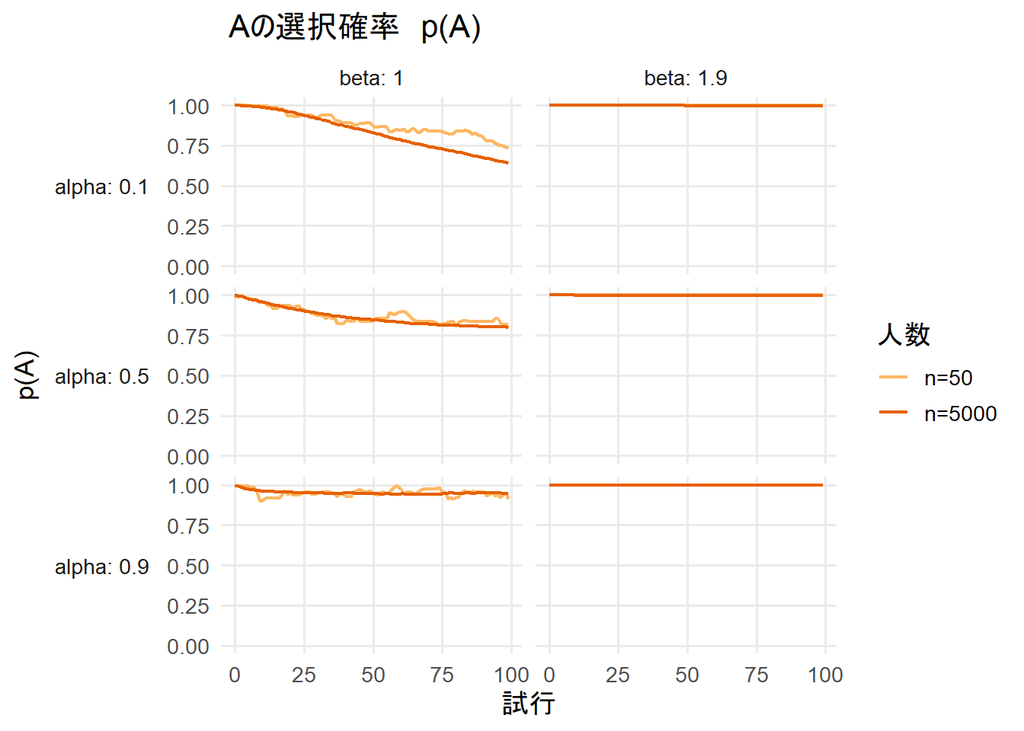

```r
plot_overlay_pA_grid(
  cfg_list   = list(cfg, cfg_ev),
  label_list = c("n=50", "n=5000"),
  root_list  = c("data", "expected_value")
)
```

# 4.フィッティング

## 4.1 stanファイルの事前分布（数式）

stanファイルは以下を使用した

```
data {
  int<lower=1> N;
  int<lower=1> T;
  array[N, T] int<lower=0, upper=1> choice;
  array[N, T] real reward_A;
  array[N, T] real reward_B;
}

parameters {
  real<lower=0, upper=1> alpha;
  real<lower=0>          beta;
  real                   Q_init1;
}

transformed parameters {
  real Q_init2 = 0;
}

model {
  alpha   ~ beta(2, 2);
  beta    ~ lognormal(log(1), 0.5);
  Q_init1 ~ normal(3.75, 2) T[0, 7.5];

  for (n in 1:N) {
    vector[2] Q = rep_vector(0.0, 2);
    Q[1] = Q_init1;
    Q[2] = Q_init2;

    for (t in 1:T) {
      real pA = inv_logit(beta * (Q[1] - Q[2]));
      choice[n, t] ~ bernoulli(pA);

      int a = choice[n, t] + 1;
      real r = (a == 1) ? reward_A[n, t] : reward_B[n, t];
      Q[a] += alpha * (r - Q[a]);
    }
  }
}

generated quantities {
  array[N, T] int<lower=0,upper=1> choice_rep;
  array[N, T] real              pA_track;

  for (n in 1:N) {
    vector[2] Q = rep_vector(0.0, 2);
    Q[1] = Q_init1;
    Q[2] = Q_init2;

    for (t in 1:T) {
      real pA = inv_logit(beta * (Q[1] - Q[2]));
      pA_track[n, t]   = pA;
      choice_rep[n, t] = bernoulli_rng(pA);

      int a = choice_rep[n, t] + 1;
      real r = (a == 1) ? reward_A[n, t] : reward_B[n, t];
      Q[a] += alpha * (r - Q[a]);
    }
  }
}
```

## 4.2 フィッティングの実行

**モデルのフィッティングのコード**

```r
fmt_dash <- function(x) gsub("\\.", "-", sprintf("%.1f", x))
join_dash <- function(v) paste(v, collapse = "-")

param_grid <- expand.grid(
  alpha = cfg$alphas,
  beta  = cfg$betas
) %>%
  mutate(
    a_str = fmt_dash(alpha),
    b_str = fmt_dash(beta),
    key   = paste0("a", a_str, "_b", b_str)
  )

fit_model <- function(cfg, alpha, beta, stan_file = "first_value.stan") {

  fmt_dash <- function(x) gsub("\\.", "-", sprintf("%.1f", x))
  join_dash <- function(v) paste(v, collapse = "-")

  folder   <- glue(
    "T{fmt_dash(cfg$T_val)}_r{join_dash(cfg$r_base)}_{cfg$n_agents}agents_rep{cfg$rep_idx}"
  )
  agent_lbl <- gsub("_", "-", cfg$agent_type)
  param_str <- if (is.na(cfg$extra_p)) "na" else fmt_dash(cfg$extra_p)
  file_bas  <- glue("{agent_lbl}_p{param_str}_a{fmt_dash(alpha)}_b{fmt_dash(beta)}.csv")
  csv_path  <- fs::path("data", folder, "csv", file_bas)

  if (!fs::file_exists(csv_path)) {
    stop("CSV が見つかりません: ", csv_path)
  }

  df   <- read.csv(csv_path)
  N    <- length(unique(df$ID))
  Tt   <- max(df$round) + 1
  stan_data <- list(
    N        = N,
    T        = Tt,
    choice   = matrix(df$choice,   nrow = N, byrow = TRUE),
    reward_A = matrix(ifelse(df$choice==0, df$reward, 0), nrow = N, byrow = TRUE),
    reward_B = matrix(ifelse(df$choice==1, df$reward, 0), nrow = N, byrow = TRUE)
  )

  mod <- cmdstan_model(stan_file)
  fit <- mod$sample(
    data          = stan_data,
    chains        = 3,
    iter_warmup   = 1000,
    iter_sampling = 1000,
    refresh       = 0
  )

  return(fit)
}
```

```r
fit_list <- param_grid %>%
  mutate(fit = purrr::pmap(
    list(alpha, beta),
    ~ fit_model(cfg, ..1, ..2)
  )) %>%
  pull(fit)
```

```
## Running MCMC with 3 sequential chains...
##
## Chain 1 finished in 8.0 seconds.
## Chain 2 finished in 7.9 seconds.
## Chain 3 finished in 7.9 seconds.
##
## All 3 chains finished successfully.
## Mean chain execution time: 7.9 seconds.
## Total execution time: 25.3 seconds.
##
## Running MCMC with 3 sequential chains...
##
## Chain 1 finished in 8.4 seconds.
## Chain 2 finished in 8.4 seconds.
## Chain 3 finished in 7.6 seconds.
##
## All 3 chains finished successfully.
## Mean chain execution time: 8.1 seconds.
## Total execution time: 25.7 seconds.
##
## Running MCMC with 3 sequential chains...
##
## Chain 1 finished in 8.0 seconds.
## Chain 2 finished in 8.8 seconds.
## Chain 3 finished in 7.6 seconds.
##
## All 3 chains finished successfully.
## Mean chain execution time: 8.1 seconds.
## Total execution time: 25.8 seconds.
##
## Running MCMC with 3 sequential chains...
##
## Chain 1 finished in 8.5 seconds.
## Chain 2 finished in 8.0 seconds.
## Chain 3 finished in 8.4 seconds.
##
## All 3 chains finished successfully.
## Mean chain execution time: 8.3 seconds.
## Total execution time: 26.2 seconds.
```

```
## Running MCMC with 3 sequential chains...
##
## Chain 1 finished in 8.5 seconds.
## Chain 2 finished in 8.4 seconds.
## Chain 3 finished in 8.6 seconds.
##
## All 3 chains finished successfully.
## Mean chain execution time: 8.5 seconds.
## Total execution time: 26.9 seconds.
```

```
## Running MCMC with 3 sequential chains...
##
## Chain 1 finished in 8.4 seconds.
## Chain 2 finished in 8.1 seconds.
## Chain 3 finished in 8.3 seconds.
##
## All 3 chains finished successfully.
## Mean chain execution time: 8.3 seconds.
## Total execution time: 26.2 seconds.
```

```r
names(fit_list) <- param_grid$key
```

```r
alpha_beta_summary <- imap_dfr(
  fit_list,
  ~ .x$summary(variables = c("alpha", "beta","Q_init1")) %>%
      as_tibble() %>%
      mutate(pattern = .y) %>%
      select(
        pattern,
        parameter = variable,
        mean, median,
        sd, mad,
        q5, q95,
        Rhat = rhat,
        ESS_bulk = ess_bulk,
        ESS_tail = ess_tail
      ),
  .id = NULL
)

knitr::kable(
  alpha_beta_summary,
  digits = 3,
  caption = "summary"
)
```

summary

| pattern | parameter | mean | median | sd | mad | q5 | q95 | Rhat | ESS_bulk | ESS_tail |
| --- | --- | --- | --- | --- | --- | --- | --- | --- | --- | --- |
| a0-1_b1-0 | alpha | 0.218 | 0.218 | 0.019 | 0.018 | 0.186 | 0.250 | 1.000 | 2275.408 | 1600.569 |
| a0-1_b1-0 | beta | 0.899 | 0.898 | 0.028 | 0.028 | 0.854 | 0.945 | 1.000 | 2807.829 | 1900.059 |
| a0-1_b1-0 | Q_init1 | 7.023 | 6.931 | 1.262 | 1.252 | 5.141 | 9.176 | 1.001 | 2186.309 | 1405.195 |
| a0-5_b1-0 | alpha | 0.399 | 0.399 | 0.012 | 0.012 | 0.379 | 0.419 | 1.002 | 2407.202 | 2214.733 |
| a0-5_b1-0 | beta | 0.932 | 0.931 | 0.029 | 0.030 | 0.887 | 0.983 | 1.001 | 2200.428 | 2237.651 |
| a0-5_b1-0 | Q_init1 | 4.505 | 4.448 | 0.902 | 0.902 | 3.132 | 6.073 | 1.000 | 2356.289 | 1808.574 |
| a0-9_b1-0 | alpha | 0.836 | 0.836 | 0.014 | 0.014 | 0.813 | 0.859 | 1.000 | 1939.650 | 1742.672 |
| a0-9_b1-0 | beta | 0.897 | 0.896 | 0.029 | 0.028 | 0.850 | 0.946 | 1.000 | 1948.554 | 1992.663 |
| a0-9_b1-0 | Q_init1 | 5.830 | 5.747 | 1.368 | 1.406 | 3.745 | 8.198 | 1.002 | 2422.669 | 1757.473 |
| a0-1_b1-9 | alpha | 0.507 | 0.506 | 0.220 | 0.253 | 0.150 | 0.868 | 1.001 | 2148.442 | 1459.824 |
| a0-1_b1-9 | beta | 2.331 | 2.167 | 0.637 | 0.495 | 1.622 | 3.583 | 1.003 | 1910.433 | 1266.049 |
| a0-1_b1-9 | Q_init1 | 4.435 | 4.254 | 1.594 | 1.608 | 2.139 | 7.255 | 1.008 | 1935.217 | 1275.810 |
| a0-5_b1-9 | alpha | 0.507 | 0.515 | 0.217 | 0.239 | 0.144 | 0.858 | 1.000 | 2031.935 | 1577.857 |
| a0-5_b1-9 | beta | 2.348 | 2.190 | 0.666 | 0.506 | 1.635 | 3.577 | 1.000 | 1773.212 | 1148.252 |
| a0-5_b1-9 | Q_init1 | 4.498 | 4.360 | 1.574 | 1.609 | 2.210 | 7.343 | 1.000 | 1921.364 | 1520.402 |
| a0-9_b1-9 | alpha | 0.501 | 0.506 | 0.218 | 0.252 | 0.143 | 0.852 | 1.001 | 1889.762 | 1402.469 |
| a0-9_b1-9 | beta | 2.360 | 2.187 | 0.673 | 0.492 | 1.632 | 3.643 | 1.000 | 1816.143 | 1183.334 |
| a0-9_b1-9 | Q_init1 | 4.592 | 4.432 | 1.633 | 1.662 | 2.231 | 7.535 | 1.001 | 1540.236 | 1594.249 |

# 5.プロット

## 5.1 traceplot

### 5.1.1 traceplot

5.1.1.1 データの読み込み

```r
param_list <- c("alpha", "beta","Q_init1")

plot_trace_facet <- function(param_name, fit_list) {
  trace_df <- dplyr::bind_rows(lapply(names(fit_list), function(model) {
    draws_df <- posterior::as_draws_df(fit_list[[model]]$draws())
    if (param_name %in% colnames(draws_df)) {
      data.frame(
        iteration = draws_df$.iteration,
        chain     = factor(draws_df$.chain),
        value     = draws_df[[param_name]],
        model     = model
      )
    }
  }))

  ggplot2::ggplot(trace_df, ggplot2::aes(x = iteration, y = value, color = chain)) +
    ggplot2::geom_line(alpha = 0.8) +
    ggplot2::facet_wrap(~model, ncol = 2) +
    ggplot2::labs(title = paste("Traceplot of", param_name),
                  x = "Iteration", y = param_name, color = "Chain") +
    ggplot2::theme_minimal()
}
```

#### 5.1.1.2 traceplot alpha

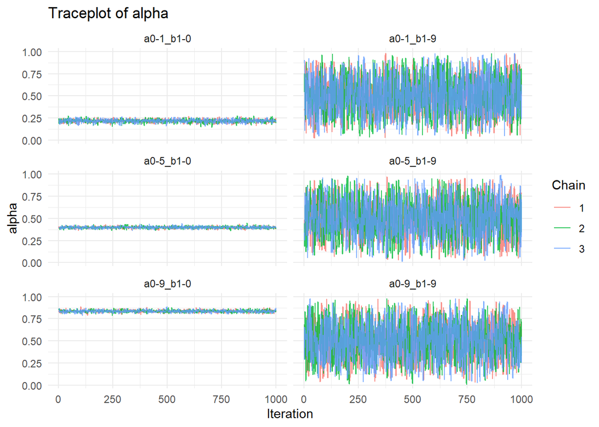

```r
plot_trace_facet("alpha", fit_list)
```

#### 5.1.1.3 traceplot beta

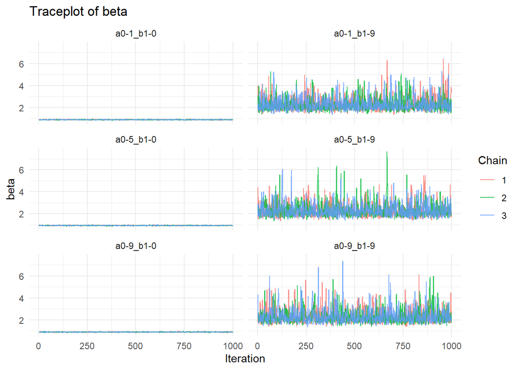

```r
plot_trace_facet("beta", fit_list)
```

#### 5.1.1.4 traceplot Q_init1

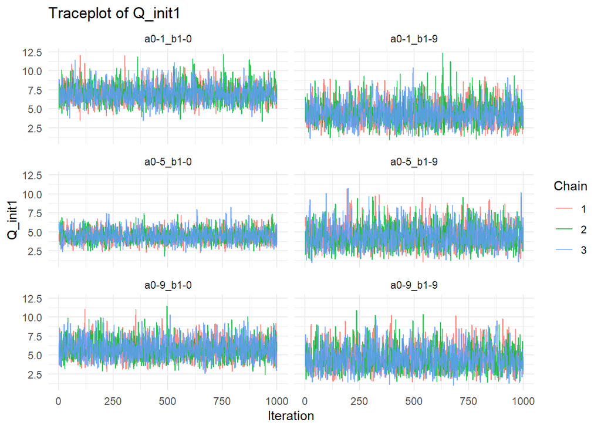

```r
plot_trace_facet("Q_init1", fit_list)
```

## 5.2事後分布

### 5.2.0 関数の作成

```r
plot_density_facet <- function(param_name, fit_list, y_max = NULL) {
  dens_df <- bind_rows(lapply(names(fit_list), function(model) {
    draws_df <- as_draws_df(fit_list[[model]]$draws(format = "df"))
    if (param_name %in% colnames(draws_df)) {
      data.frame(
        value = draws_df[[param_name]],
        chain = as.factor(draws_df$.chain),
        model = model
      )
    } else {
      NULL
    }
  }))

  p <- ggplot(dens_df, aes(x = value, color = chain, fill = chain)) +
    geom_density(alpha = 0.3) +
    facet_wrap(~model, ncol = 2) +
    labs(title = paste("Posterior distribution of", param_name),
         x = param_name, y = "Density", color = "Chain", fill = "Chain") +
    theme_minimal()

  if (!is.null(y_max)) {
    p <- p + coord_cartesian(ylim = c(0, y_max))
  }

  return(p)
}
```

#### 5.2.1.1 alpha

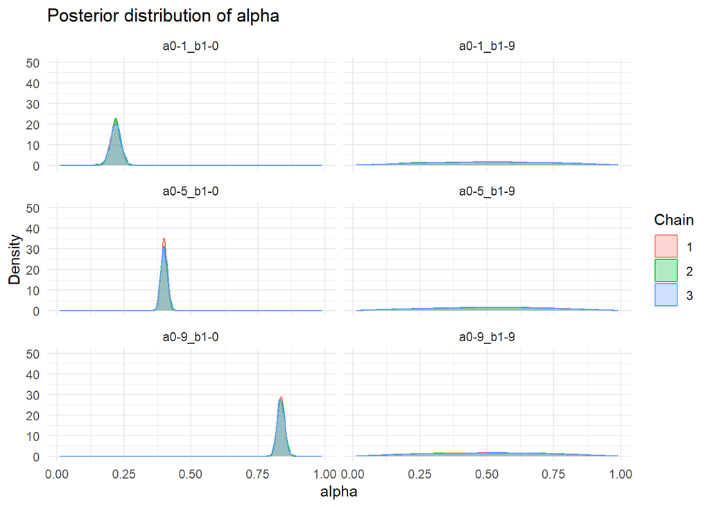

```r
plot_density_facet("alpha", fit_list, y_max = 50)
```

#### 5.2.1.2 beta

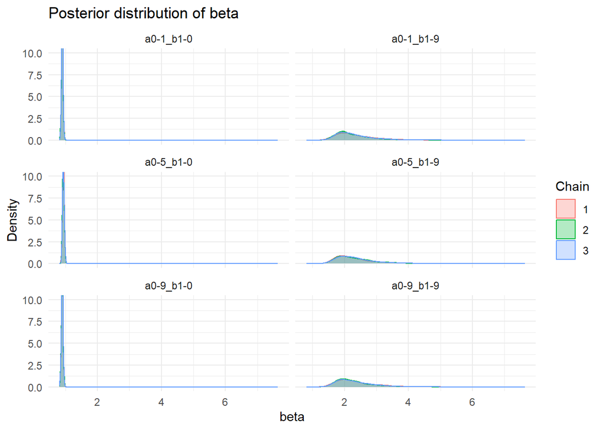

```r
plot_density_facet("beta", fit_list, y_max = 10)
```

#### 5.2.1.3 Q_init1

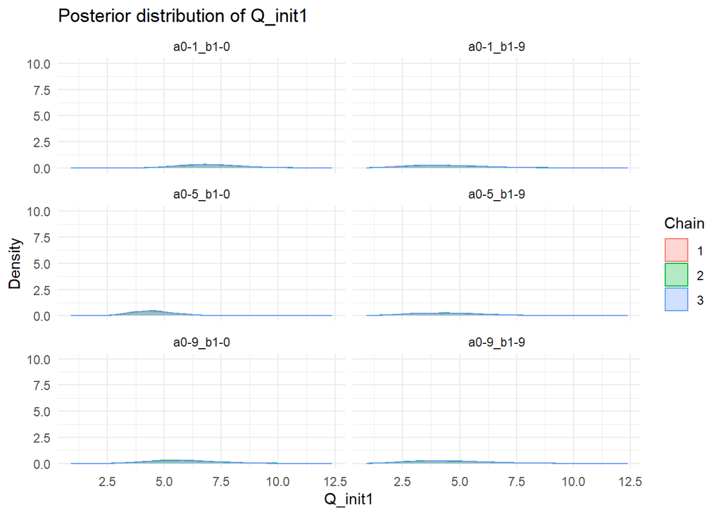

```r
plot_density_facet("Q_init1", fit_list, y_max = 10)
```

## 5.3 実際の選択確率

5.3.1 前処理

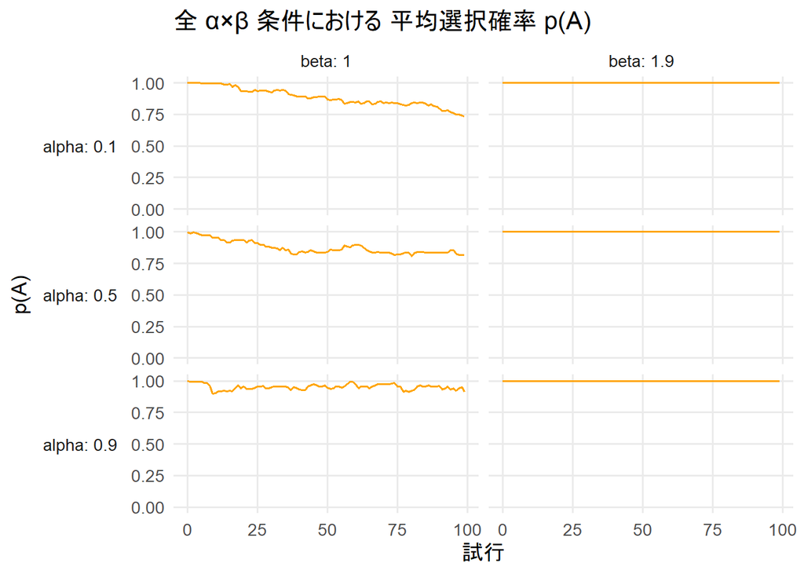

```r
fstr <- function(x) gsub("\\.", "-", sprintf("%.1f", x))

folder_name <- sprintf("data/T%s_r%s_%sagents_rep%s",
  fstr(cfg$T_val),
  paste(cfg$r_base, collapse = "-"),
  cfg$n_agents,
  cfg$rep_idx
)
csv_dir <- file.path(folder_name, "csv")

df_all <- list()

for (alpha in cfg$alphas) {
  for (beta in cfg$betas) {
    t_label   <- paste0("p", fstr(cfg$extra_p))
    file_name <- sprintf("%s_%s_a%s_b%s_pA.csv",
      cfg$agent_type,
      t_label,
      fstr(alpha),
      fstr(beta)
    )
    file_path <- file.path(csv_dir, file_name)
    if (file.exists(file_path)) {
      raw <- readr::read_csv(file_path, show_col_types = FALSE)
      df_all[[length(df_all) + 1]] <- raw %>%
        dplyr::mutate(alpha = alpha, beta = beta)
    } else {
      warning("ファイルが存在しません: ", file_path)
    }
  }
}

df_pA_all <- dplyr::bind_rows(df_all) %>%
  dplyr::mutate(
    alpha = factor(alpha, levels = sort(unique(cfg$alphas))),
    beta  = factor(beta,  levels = sort(unique(cfg$betas)))
  )

ggplot2::ggplot(df_pA_all, ggplot2::aes(x = trial, y = pA, group = interaction(alpha, beta))) +
  ggplot2::geom_line(color = "orange", linewidth = 0.7) +
  ggplot2::facet_grid(alpha ~ beta, labeller = ggplot2::label_both, switch = "y") +
  ggplot2::coord_cartesian(ylim = c(0, 1)) +
  ggplot2::theme_minimal(base_size = 13) +
  ggplot2::theme(
    strip.placement   = "outside",
    strip.text.y.left = ggplot2::element_text(angle = 0),
    panel.grid.minor  = ggplot2::element_blank()
  ) +
  ggplot2::labs(
    title = "全 α×β 条件における 平均選択確率 p(A)",
    x     = "試行",
    y     = "p(A)"
  )
```